# Handson Praktikum 1 MPDW

# I. Import Library

Pada bagian awal ini, dilakukan pemanggilan seluruh package R yang dibutuhkan selama proses analisis.

1. forecast: Menyediakan fungsi-fungsi utama untuk peramalan (misalnya fungsi forecast()).
2. graphics & ggplot2: Digunakan untuk membuat visualisasi grafik data secara intuitif dan menarik.
3. TTR: Berisi fungsi teknik analisis time series, seperti fungsi SMA() untuk menghitung moving average.
4. TSA: Menyediakan utilitas statistik analisis deret waktu.

```r
library(forecast)
library(graphics)
library(TTR)
library(TSA)
library(ggplot2)
```

# II. Pre-processing Data

Chunk ini berfokus pada persiapan data sebelum pemodelan dilakukan:

1. Impor Data: Mengimpor file CSV harga cabai menggunakan delimiter ; (read.csv2).
2. Konversi Time Series: Mengubah kolom harga menjadi objek deret waktu (ts).
3. Pembagian Data (Data Splitting): Data dibagi menjadi 80% Data Latih (Training) dan 20% Data Uji (Testing). Data latih digunakan untuk melatih/membentuk model pemulusan, sedangkan data uji disimpan sebagai pembanding untuk mengevaluasi kemampuan ramalan model pada periode mendatang.

```r
data <- read.csv2("C:\\Users\\a c e r\\Downloads\\MPDW Cabai merah.csv")

data.ts <- ts(data$Harga.Cabai..Ribu.Rupiah.)

n <- nrow(data)
n_train <- floor(0.8 * n) # 80% Train

training_ma <- data[1:n_train, ]
testing_ma  <- data[(n_train + 1):n, ]

train_ma.ts <- ts(training_ma$Harga.Cabai..Ribu.Rupiah.)
test_ma.ts  <- ts(testing_ma$Harga.Cabai..Ribu.Rupiah.)
```

# III. Eksplorasi Data

[figure not shown]

```r
ggplot() +
  geom_line(data = training_ma, aes(x = Tanggal, y = Harga.Cabai..Ribu.Rupiah., col = "Data Latih", group = 1)) +
  geom_line(data = testing_ma,  aes(x = Tanggal, y = Harga.Cabai..Ribu.Rupiah., col = "Data Uji", group = 1)) +
  labs(title = "Eksplorasi Data Harga Cabai", x = "Tanggal", y = "Harga Cabai", color = "Keterangan:") +
  scale_colour_manual(values = c("Data Latih" = "blue", "Data Uji" = "red")) +
  theme_bw() +
  theme(
    legend.position = "bottom",
    plot.title = element_text(hjust = 0.5, face = "bold")
  )
```

# IV. Single Moving Average (SMA)

Metode SMA cocok digunakan untuk data stasioner (tanpa tren tajam dan tanpa pola musiman).

## 1. Pemulusan SMA (n = 2)

Pemulusan (n=2): Menghitung nilai rata-rata bergerak menggunakan orde $n=2$ dari data latih.

```r
data.sma <- SMA(train_ma.ts, n = 2)
```

## 2. Peramalan 1 periode ke depan untuk data latih

Peramalan Latih: Menyesuaikan nilai ramalan data latih dengan menggeser 1 periode ke depan (c(NA, data.sma)).

```r
data.ramal.sma <- c(NA, data.sma)
```

## 3. Peramalan 259 periode ke depan untuk data uji

Peramalan Uji: Karakteristik utama SMA adalah nilai ramalan untuk periode $h$-step ke depan bersifat konstan (datar), yaitu sama dengan nilai pemulusan terakhir dari data latih.

```r
n_test <- length(test_ma.ts)
ramalan_sma_test <- rep(data.ramal.sma[length(data.ramal.sma)], n_test)
```

## 4. Penggabungan Data (Total 1294 observasi)

Penggabungan Data: Menyusun data aktual, hasil pemulusan, dan hasil peramalan ke dalam satu matriks/tabel tunggal berukuran 1294 observasi.

```r
data.gab.sma <- cbind(
  aktual    = c(data.ts),
  pemulusan = c(data.sma, rep(NA, n_test)),
  ramalan   = c(data.ramal.sma, ramalan_sma_test[-1])
)
```

## 5. Visualisasi Plot SMA

Visualisasi Plot: Menampilkan grafik perbandingan antara data aktual (hitam), pemulusan (hijau), dan peramalan (merah).

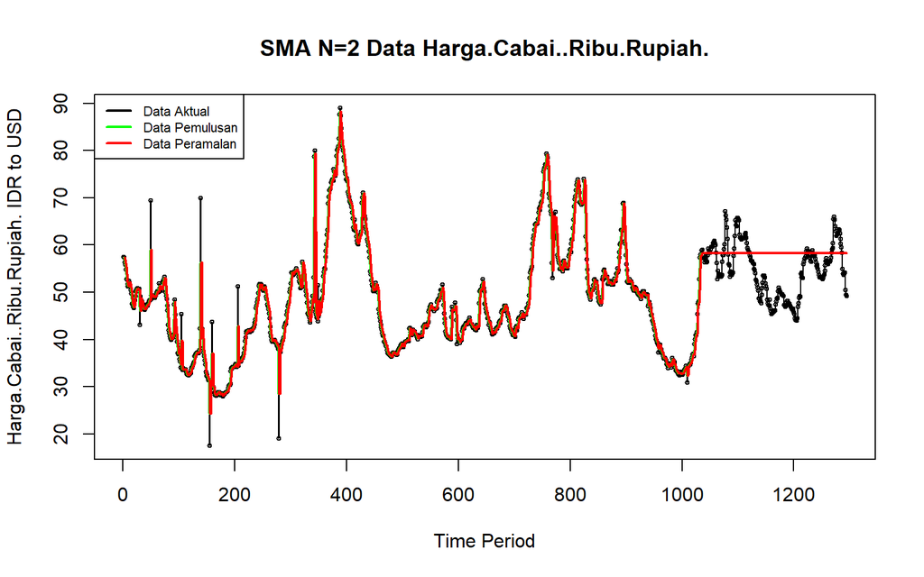

```r
ts.plot(data.ts, xlab = "Time Period", ylab = "Harga.Cabai..Ribu.Rupiah. IDR to USD", main = "SMA N=2 Data Harga.Cabai..Ribu.Rupiah.")
points(data.ts, cex = 0.5)
lines(data.gab.sma[, "pemulusan"], col = "green", lwd = 2)
lines(data.gab.sma[, "ramalan"], col = "red", lwd = 2)
legend("topleft", legend = c("Data Aktual", "Data Pemulusan", "Data Peramalan"),
       col = c("black", "green", "red"), lty = 1, lwd = 2, cex = 0.7)
```

## 6. Akurasi Data Latih

Akurasi Latih & Uji: Menghitung ukuran kebaikan model menggunakan SSE, MSE, dan MAPE (%).

```r
error_train.sma  <- train_ma.ts - data.ramal.sma[1:n_train]
SSE_train.sma    <- sum(error_train.sma[3:n_train]^2, na.rm = TRUE)
MSE_train.sma    <- mean(error_train.sma[3:n_train]^2, na.rm = TRUE)
MAPE_train.sma   <- mean(abs(error_train.sma[3:n_train] / train_ma.ts[3:n_train]) * 100, na.rm = TRUE)

akurasi_train.sma <- matrix(c(SSE_train.sma, MSE_train.sma, MAPE_train.sma),
                            dimnames = list(c("SSE", "MSE", "MAPE (%)"), "Akurasi Train (n=2)"))
```

## 7. Akurasi Data Uji

```r
error_test.sma  <- test_ma.ts - data.gab.sma[(n_train + 1):n, "ramalan"]
SSE_test.sma    <- sum(error_test.sma^2)
MSE_test.sma    <- mean(error_test.sma^2)
MAPE_test.sma   <- mean(abs(error_test.sma / test_ma.ts) * 100)

akurasi_test.sma <- matrix(c(SSE_test.sma, MSE_test.sma, MAPE_test.sma),
                           dimnames = list(c("SSE", "MSE", "MAPE (%)"), "Akurasi Test (n=2)"))

cbind(akurasi_train.sma, akurasi_test.sma)
```

```
##          Akurasi Train (n=2) Akurasi Test (n=2)
## SSE              8927.953750       10725.641875
## MSE                 8.642743          41.411745
## MAPE (%)            2.841591           9.989339
```

## 8. Interpretasi

Hasil evaluasi model Single Moving Average (SMA) dengan orde $n=2$ menunjukkan tingkat akurasi yang sangat baik (highly accurate), ditunjukkan oleh nilai MAPE sebesar 2,84% pada data latih dan 9,99% pada data uji—keduanya berada di bawah ambang batas 10%. Meskipun nilai kesalahan kuadrat meningkat pada data uji (SSE = 10725,64 dan MSE = 41,41) akibat sifat peramalan SMA yang menghasilkan nilai konstan (mendatar) untuk periode mendatang, nilai rata-rata penyimpangan ramalan secara keseluruhan tetap tergolong sangat presisi dan layak digunakan sebagai metode pemulusan.

# V. Double Moving Average (DMA)

Metode DMA dirancang untuk mengatasi kelemahan SMA jika data memiliki pola tren.

Komponen $A_t$ dan $B_t$: Menghitung pemulusan tingkat kedua (dma) dari hasil pemulusan pertama (data.sma), kemudian menentukan parameter level ($A_t$) dan trend ($B_t$).

Peramalan Data Uji (Looping): Berbeda dari SMA yang mendatar, peramalan DMA memanfaatkan persamaan garis linier:

$$\hat{Y}_{t+h} = A_t + B_t \times
h$$

Sehingga garis peramalan pada data uji akan mengikuti kemiringan/tren ($B_t$).

## 1. Pemulusan Tahap II & Komponen At, Bt (n = 2)

```r
dma <- SMA(data.sma, n = 2)
At  <- 2 * data.sma - dma
Bt  <- (2 / (2 - 1)) * (data.sma - dma)
```

## 2. Pemulusan & Fitting Data Latih

```r
data.dma <- At + Bt
data.ramal.dma <- c(NA, data.dma)
```

## 3. Peramalan 259 periode ke depan untuk data uji

```r
n_test <- length(test_ma.ts)
f_dma  <- numeric(n_test)
At_last <- At[length(At)]
Bt_last <- Bt[length(Bt)]

for (h in 1:n_test) {
  f_dma[h] <- At_last + Bt_last * h
}
```

## 4. Penggabungan Data (1294 Amatab)

```r
data.gab.dma <- cbind(
  aktual     = c(data.ts),
  pemulusan1 = c(data.sma, rep(NA, n_test)),
  pemulusan2 = c(dma, rep(NA, n_test)),
  At         = c(At, rep(NA, n_test)),
  Bt         = c(Bt, rep(NA, n_test)),
  ramalan    = c(data.ramal.dma, f_dma[-1])
)
```

## 5. Visualisasi Plot DMA

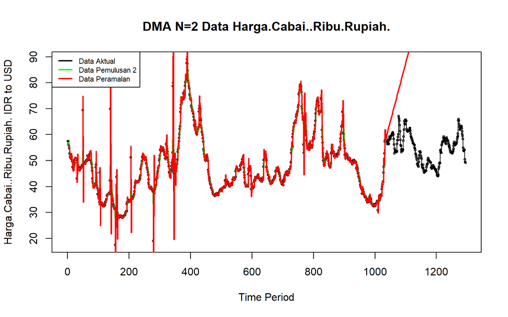

```r
ts.plot(data.ts, xlab = "Time Period", ylab = "Harga.Cabai..Ribu.Rupiah. IDR to USD", main = "DMA N=2 Data Harga.Cabai..Ribu.Rupiah.")
points(data.ts, cex = 0.5)
lines(data.gab.dma[, "pemulusan2"], col = "green", lwd = 2)
lines(data.gab.dma[, "ramalan"], col = "red", lwd = 2)
legend("topleft", legend = c("Data Aktual", "Data Pemulusan 2", "Data Peramalan"),
       col = c("black", "green", "red"), lty = 1, lwd = 2, cex = 0.7)
```

## 6. Akurasi Data Latih (Evaluasi dimulai dari indeks n=4)

```r
error_train.dma  <- train_ma.ts - data.ramal.dma[1:n_train]
SSE_train.dma    <- sum(error_train.dma[4:n_train]^2, na.rm = TRUE)
MSE_train.dma    <- mean(error_train.dma[4:n_train]^2, na.rm = TRUE)
MAPE_train.dma   <- mean(abs(error_train.dma[4:n_train] / train_ma.ts[4:n_train]) * 100, na.rm = TRUE)

akurasi_train.dma <- matrix(c(SSE_train.dma, MSE_train.dma, MAPE_train.dma),
                            dimnames = list(c("SSE", "MSE", "MAPE (%)"), "Akurasi Train (n=2)"))
```

## 7. Akurasi Data Uji

Akurasi: Penghitungan evaluasi kelayakan dimulai dari indeks ke-4 ($n=4$) untuk memperhitungkan periode lag akibat dua kali pemulusan moving average.

```r
error_test.dma  <- test_ma.ts - data.gab.dma[(n_train + 1):n, "ramalan"]
SSE_test.dma    <- sum(error_test.dma^2)
MSE_test.dma    <- mean(error_test.dma^2)
MAPE_test.dma   <- mean(abs(error_test.dma / test_ma.ts) * 100)

akurasi_test.dma <- matrix(c(SSE_test.dma, MSE_test.dma, MAPE_test.dma),
                           dimnames = list(c("SSE", "MSE", "MAPE (%)"), "Akurasi Test (n=2)"))

cbind(akurasi_train.dma, akurasi_test.dma)
```

```
##          Akurasi Train (n=2) Akurasi Test (n=2)
## SSE             15317.040938       1310289.4225
## MSE                14.842094          5059.0325
## MAPE (%)            3.164664           115.8433
```

## 8. Interpretasi

Hasil evaluasi metode Double Moving Average (DMA) dengan orde $n=2$ menunjukkan performa yang sangat baik pada data latih (MAPE 3,16%; MSE 14,84), namun mengalami perburukan ekstrem pada data uji dengan nilai MAPE mencapai 115,84% serta MSE membengkak hingga 5059,03. Lonjakan kesalahan yang sangat tinggi pada data uji ini (overfitting) mengindikasikan bahwa proyeksi garis tren linier yang dibentuk DMA ($n=2$) terlalu sensitif terhadap fluktuasi lokal di akhir data latih, sehingga garis ramalannya melenceng jauh dari pola aktual di masa depan dan menjadikan metode DMA tidak layak digunakan untuk peramalan data uji ini.

# VI. Single Exponential Smoothing (SES)

SES merupakan metode pemulusan eksponensial untuk data yang fluktuatif tanpa pola tren/musiman yang jelas, di mana data terbaru diberikan bobot eksponensial yang lebih besar (dikontrol oleh parameter pemulusan $\alpha$).

Trial Parameter: Mencoba tiga skenario parameter pemulusan: $\alpha = 0.2$ (pemulusan kaku/lambat), $\alpha = 0.7$ (pemulusan responsif), dan $\alpha\text{ Optimum}$ (pencarian nilai $\alpha$ terbaik secara otomatis oleh R untuk meminimalkan SSE).

```r
ses.1   <- HoltWinters(train_ma.ts, gamma = FALSE, beta = FALSE, alpha = 0.2)
ses.2   <- HoltWinters(train_ma.ts, gamma = FALSE, beta = FALSE, alpha = 0.7)
ses.opt <- HoltWinters(train_ma.ts, gamma = FALSE, beta = FALSE, alpha = NULL)
```

## 2. Peramalan 259 periode ke depan untuk Data Uji

```r
ramalan_ses1   <- forecast(ses.1, h = n_test)
ramalan_ses2   <- forecast(ses.2, h = n_test)
ramalan_sesopt <- forecast(ses.opt, h = n_test)
```

## 3. Visualisasi Hasil Pemulusan & Peramalan SES Optimum

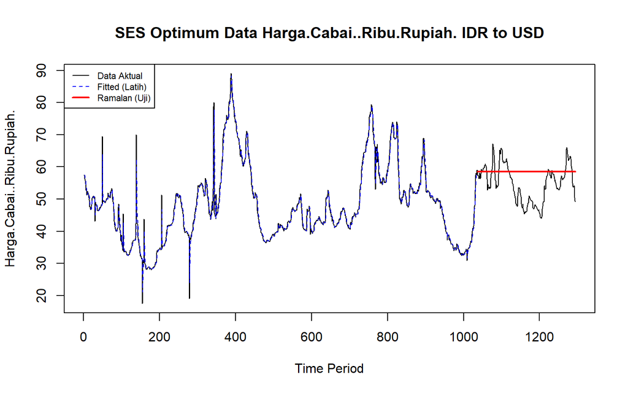

```r
plot(data.ts, main = "SES Optimum Data Harga.Cabai..Ribu.Rupiah. IDR to USD", xlab = "Time Period", ylab = "Harga.Cabai..Ribu.Rupiah.")
lines(ses.opt$fitted[, 1], col = "blue", lty = 2)
lines(ramalan_sesopt$mean, col = "red", lwd = 2)
legend("topleft", legend = c("Data Aktual", "Fitted (Latih)", "Ramalan (Uji)"),
       col = c("black", "blue", "red"), lty = c(1, 2, 1), lwd = c(1, 1, 2), cex = 0.7)
```

## 4. Akurasi Data Latih

```r
# alpha = 0.2
sisaan_ses1 <- ramalan_ses1$residuals
SSE_train.ses1  <- sum(sisaan_ses1[2:n_train]^2, na.rm = TRUE)
MSE_train.ses1  <- SSE_train.ses1 / n_train
RMSE_train.ses1 <- sqrt(MSE_train.ses1)
MAPE_train.ses1 <- mean(abs(sisaan_ses1[2:n_train] / train_ma.ts[2:n_train]) * 100, na.rm = TRUE)

# alpha = 0.7
sisaan_ses2 <- ramalan_ses2$residuals
SSE_train.ses2  <- sum(sisaan_ses2[2:n_train]^2, na.rm = TRUE)
MSE_train.ses2  <- SSE_train.ses2 / n_train
RMSE_train.ses2 <- sqrt(MSE_train.ses2)
MAPE_train.ses2 <- mean(abs(sisaan_ses2[2:n_train] / train_ma.ts[2:n_train]) * 100, na.rm = TRUE)

# alpha Optimum
sisaan_sesopt <- ramalan_sesopt$residuals
SSE_train.sesopt  <- sum(sisaan_sesopt[2:n_train]^2, na.rm = TRUE)
MSE_train.sesopt  <- SSE_train.sesopt / n_train
RMSE_train.sesopt <- sqrt(MSE_train.sesopt)
MAPE_train.sesopt <- mean(abs(sisaan_sesopt[2:n_train] / train_ma.ts[2:n_train]) * 100, na.rm = TRUE)

akurasi_train.ses <- matrix(
  c(SSE_train.ses1, MSE_train.ses1, RMSE_train.ses1, MAPE_train.ses1,
    SSE_train.ses2, MSE_train.ses2, RMSE_train.ses2, MAPE_train.ses2,
    SSE_train.sesopt, MSE_train.sesopt, RMSE_train.sesopt, MAPE_train.sesopt),
  nrow = 4, ncol = 3,
  dimnames = list(c("SSE", "MSE", "RMSE", "MAPE (%)"), c("SES (a=0.2)", "SES (a=0.7)", "SES (Opt)"))
)

# 5. Akurasi Data Uji (Manual)
selisih_ses1   <- as.numeric(ramalan_ses1$mean) - as.numeric(test_ma.ts)
selisih_ses2   <- as.numeric(ramalan_ses2$mean) - as.numeric(test_ma.ts)
selisih_sesopt <- as.numeric(ramalan_sesopt$mean) - as.numeric(test_ma.ts)

SSE_test.ses1  <- sum(selisih_ses1^2)
MSE_test.ses1  <- mean(selisih_ses1^2)
RMSE_test.ses1 <- sqrt(MSE_test.ses1)
MAPE_test.ses1 <- mean(abs(selisih_ses1 / test_ma.ts) * 100)

SSE_test.ses2  <- sum(selisih_ses2^2)
MSE_test.ses2  <- mean(selisih_ses2^2)
RMSE_test.ses2 <- sqrt(MSE_test.ses2)
MAPE_test.ses2 <- mean(abs(selisih_ses2 / test_ma.ts) * 100)

SSE_test.sesopt  <- sum(selisih_sesopt^2)
MSE_test.sesopt  <- mean(selisih_sesopt^2)
RMSE_test.sesopt <- sqrt(MSE_test.sesopt)
MAPE_test.sesopt <- mean(abs(selisih_sesopt / test_ma.ts) * 100)

akurasi_test.ses <- matrix(
  c(SSE_test.ses1, MSE_test.ses1, RMSE_test.ses1, MAPE_test.ses1,
    SSE_test.ses2, MSE_test.ses2, RMSE_test.ses2, MAPE_test.ses2,
    SSE_test.sesopt, MSE_test.sesopt, RMSE_test.sesopt, MAPE_test.sesopt),
  nrow = 4, ncol = 3,
  dimnames = list(c("SSE", "MSE", "RMSE", "MAPE (%)"), c("SES (a=0.2)", "SES (a=0.7)", "SES (Opt)"))
)

# Tampilkan Hasil Akurasi
list(`Akurasi Data Latih SES` = akurasi_train.ses, `Akurasi Data Uji SES` = akurasi_test.ses)
```

```
## $`Akurasi Data Latih SES`
##           SES (a=0.2) SES (a=0.7)   SES (Opt)
## SSE      14452.007966 8086.969415 8073.818026
## MSE         13.963293    7.813497    7.800790
## RMSE         3.736749    2.795263    2.792990
## MAPE (%)     5.082753    2.666641    2.598718
##
## $`Akurasi Data Uji SES`
##          SES (a=0.2)  SES (a=0.7)    SES (Opt)
## SSE      9066.690517 11197.573923 11336.523804
## MSE        35.006527    43.233876    43.770362
## RMSE        5.916631     6.575247     6.615917
## MAPE (%)    8.952892    10.227027    10.300117
```

## 5. Interpretasi

Hasil evaluasi Single Exponential Smoothing (SES) menunjukkan bahwa skenario SES ($\alpha=0.2$) memberikan performa peramalan terbaik pada data uji dengan tingkat akurasi sangat presisi (MAPE = 8,95%; MSE = 35,01; RMSE = 5,92), berada di bawah ambang batas kesalahan 10%. Sebaliknya, skenario SES ($\alpha=0.7$) dan SES Optimum meskipun menghasilkan akurasi yang sedikit lebih tinggi pada data latih (MAPE masing-masing 2,67% dan 2,60%), keduanya justru mengalami penurunan performa pada data uji dengan nilai MAPE di atas 10% (10,23% dan 10,30%). Hal ini mengindikasikan bahwa nilai $\alpha$ yang lebih kecil ($\alpha=0.2$) lebih efektif meredam fluktuasi acak data dan menghasilkan kemampuan generalisasi yang lebih stabil untuk meramalkan periode mendatang.

# VII. Double Exponential Smoothing (DES)

Metode DES digunakan ketika data deret waktu mengandung komponen tren (naik atau turun), dengan memuat dua parameter: $\alpha$ untuk level dan $\beta$ untuk trend.

## 1. Pemulusan DES (Skenario 1, Skenario 2, dan Optimum)

```r
des.1   <- HoltWinters(train_ma.ts, gamma = FALSE, beta = 0.2, alpha = 0.2)
des.2   <- HoltWinters(train_ma.ts, gamma = FALSE, beta = 0.3, alpha = 0.6)
des.opt <- HoltWinters(train_ma.ts, gamma = FALSE, beta = NULL, alpha = NULL)
```

```r
ramalan_des1   <- forecast(des.1, h = n_test)
ramalan_des2   <- forecast(des.2, h = n_test)
ramalan_desopt <- forecast(des.opt, h = n_test)
```

## 3. Visualisasi Hasil Pemulusan & Peramalan DES Optimum

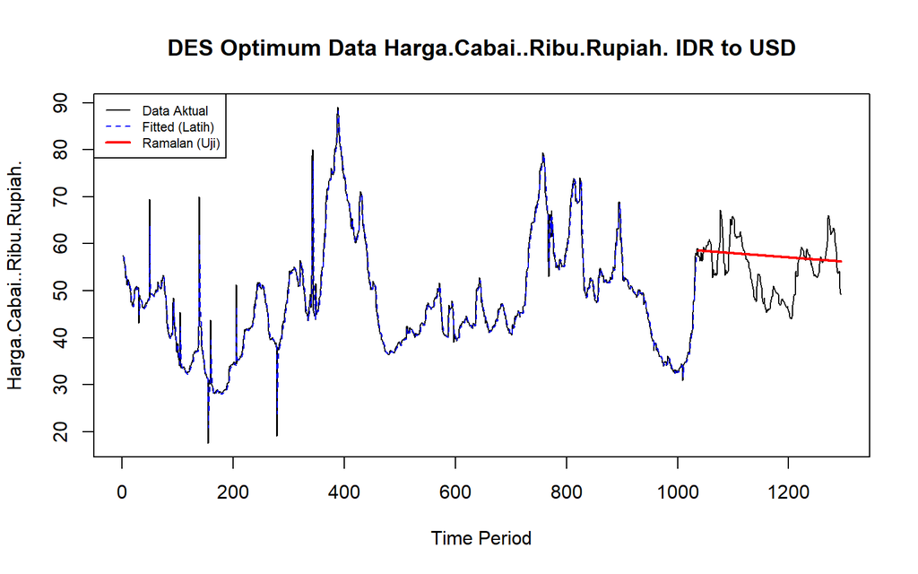

```r
plot(data.ts, main = "DES Optimum Data Harga.Cabai..Ribu.Rupiah. IDR to USD", xlab = "Time Period", ylab = "Harga.Cabai..Ribu.Rupiah.")
lines(des.opt$fitted[, 1], col = "blue", lty = 2)
lines(ramalan_desopt$mean, col = "red", lwd = 2)
legend("topleft", legend = c("Data Aktual", "Fitted (Latih)", "Ramalan (Uji)"),
       col = c("black", "blue", "red"), lty = c(1, 2, 1), lwd = c(1, 1, 2), cex = 0.7)
```

## 4. Akurasi Data Latih (Manual)

```r
# Skenario 1 (a=0.2, b=0.2)
sisaan_des1 <- ramalan_des1$residuals
SSE_train.des1  <- sum(sisaan_des1[3:n_train]^2, na.rm = TRUE)
MSE_train.des1  <- SSE_train.des1 / n_train
RMSE_train.des1 <- sqrt(MSE_train.des1)
MAPE_train.des1 <- mean(abs(sisaan_des1[3:n_train] / train_ma.ts[3:n_train]) * 100, na.rm = TRUE)

# Skenario 2 (a=0.6, b=0.3)
sisaan_des2 <- ramalan_des2$residuals
SSE_train.des2  <- sum(sisaan_des2[3:n_train]^2, na.rm = TRUE)
MSE_train.des2  <- SSE_train.des2 / n_train
RMSE_train.des2 <- sqrt(MSE_train.des2)
MAPE_train.des2 <- mean(abs(sisaan_des2[3:n_train] / train_ma.ts[3:n_train]) * 100, na.rm = TRUE)

# DES Optimum
sisaan_desopt <- ramalan_desopt$residuals
SSE_train.desopt  <- sum(sisaan_desopt[3:n_train]^2, na.rm = TRUE)
MSE_train.desopt  <- SSE_train.desopt / n_train
RMSE_train.desopt <- sqrt(MSE_train.desopt)
MAPE_train.desopt <- mean(abs(sisaan_desopt[3:n_train] / train_ma.ts[3:n_train]) * 100, na.rm = TRUE)

akurasi_train.des <- matrix(
  c(SSE_train.des1, MSE_train.des1, RMSE_train.des1, MAPE_train.des1,
    SSE_train.des2, MSE_train.des2, RMSE_train.des2, MAPE_train.des2,
    SSE_train.desopt, MSE_train.desopt, RMSE_train.desopt, MAPE_train.desopt),
  nrow = 4, ncol = 3,
  dimnames = list(c("SSE", "MSE", "RMSE", "MAPE (%)"), c("DES (Ske 1)", "DES (Ske 2)", "DES (Opt)"))
)
```

## 5. Akurasi Data Uji (Manual)

```r
selisih_des1   <- as.numeric(ramalan_des1$mean) - as.numeric(test_ma.ts)
selisih_des2   <- as.numeric(ramalan_des2$mean) - as.numeric(test_ma.ts)
selisih_desopt <- as.numeric(ramalan_desopt$mean) - as.numeric(test_ma.ts)

SSE_test.des1  <- sum(selisih_des1^2)
MSE_test.des1  <- mean(selisih_des1^2)
RMSE_test.des1 <- sqrt(MSE_test.des1)
MAPE_test.des1 <- mean(abs(selisih_des1 / test_ma.ts) * 100)

SSE_test.des2  <- sum(selisih_des2^2)
MSE_test.des2  <- mean(selisih_des2^2)
RMSE_test.des2 <- sqrt(MSE_test.des2)
MAPE_test.des2 <- mean(abs(selisih_des2 / test_ma.ts) * 100)

SSE_test.desopt  <- sum(selisih_desopt^2)
MSE_test.desopt  <- mean(selisih_desopt^2)
RMSE_test.desopt <- sqrt(MSE_test.desopt)
MAPE_test.desopt <- mean(abs(selisih_desopt / test_ma.ts) * 100)

akurasi_test.des <- matrix(
  c(SSE_test.des1, MSE_test.des1, RMSE_test.des1, MAPE_test.des1,
    SSE_test.des2, MSE_test.des2, RMSE_test.des2, MAPE_test.des2,
    SSE_test.desopt, MSE_test.desopt, RMSE_test.desopt, MAPE_test.desopt),
  nrow = 4, ncol = 3,
  dimnames = list(c("SSE", "MSE", "RMSE", "MAPE (%)"), c("DES (Ske 1)", "DES (Ske 2)", "DES (Opt)"))
)

# Tampilkan Hasil Akurasi
list(`Akurasi Data Latih DES` = akurasi_train.des, `Akurasi Data Uji DES` = akurasi_test.des)
```

```
## $`Akurasi Data Latih DES`
##           DES (Ske 1) DES (Ske 2)   DES (Opt)
## SSE      14050.402039 9258.998868 8096.228187
## MSE         13.575268    8.945893    7.822443
## RMSE         3.684463    2.990969    2.796863
## MAPE (%)     4.834700    2.738911    2.618682
##
## $`Akurasi Data Uji DES`
##           DES (Ske 1)  DES (Ske 2)   DES (Opt)
## SSE      2.150151e+07 1.529766e+07 9335.691524
## MSE      8.301741e+04 5.906434e+04   36.045141
## RMSE     2.881274e+02 2.430316e+02    6.003761
## MAPE (%) 4.649087e+02 3.929360e+02    9.249558
```

## 6. Interpretasi

Hasil evaluasi Double Exponential Smoothing (DES) menunjukkan perbedaan performa yang sangat kontras, di mana model DES Optimum tampil paling unggul dengan akurasi sangat presisi pada data uji (MAPE = 9,25%; MSE = 36,05; RMSE = 6,00), menjadikannya satu-satunya skenario DES yang layak digunakan. Sebaliknya, DES Skenario 1 dan DES Skenario 2 mengalami overfitting atau error explosion parah pada data uji dengan MAPE mencapai 464,91% dan 392,94% (serta nilai SSE mencapai orde $10^7$). Hal ini membuktikan bahwa penentuan nilai parameter $\alpha$ dan $\beta$ secara manual (Skenario 1 dan 2) menghasilkan proyeksi tren yang terlalu ekstrem, sedangkan pendekatan DES Optimum berhasil menyesuaikan komponen level dan trend secara seimbang sehingga menghasilkan peramalan jangka panjang yang sangat stabil dan akurat.

# VIII. Holt-Winters

Metode Holt-Winters digunakan jika data memiliki pola musiman (misalnya siklus mingguan, bulanan, atau berulang) serta pola tren.

## 1. Penyiapan Time Series Berfrekuensi Musiman

```r
train_hw.ts <- ts(training_ma$Harga.Cabai..Ribu.Rupiah., frequency = 5)
test_hw.ts  <- ts(testing_ma$Harga.Cabai..Ribu.Rupiah., frequency = 5)
```

## 2. Pemulusan Holt-Winters Aditif & Multiplikatif (Optimum)

```r
hw_add.opt  <- HoltWinters(train_hw.ts, seasonal = "additive")
hw_mult.opt <- HoltWinters(train_hw.ts, seasonal = "multiplicative")
```

```r
ramalan_hw_add  <- forecast(hw_add.opt, h = n_test)
ramalan_hw_mult <- forecast(hw_mult.opt, h = n_test)
```

## 4. Akurasi Data Uji Holt-Winters

```r
selisih_hw_add  <- as.numeric(ramalan_hw_add$mean) - as.numeric(test_hw.ts)
selisih_hw_mult <- as.numeric(ramalan_hw_mult$mean) - as.numeric(test_hw.ts)

SSE_test.hw_add  <- sum(selisih_hw_add^2)
MSE_test.hw_add  <- mean(selisih_hw_add^2)
RMSE_test.hw_add <- sqrt(MSE_test.hw_add)
MAPE_test.hw_add <- mean(abs(selisih_hw_add / test_hw.ts) * 100)

SSE_test.hw_mult  <- sum(selisih_hw_mult^2)
MSE_test.hw_mult  <- mean(selisih_hw_mult^2)
RMSE_test.hw_mult <- sqrt(MSE_test.hw_mult)
MAPE_test.hw_mult <- mean(abs(selisih_hw_mult / test_hw.ts) * 100)

akurasi_test.hw <- matrix(
  c(SSE_test.hw_add, MSE_test.hw_add, RMSE_test.hw_add, MAPE_test.hw_add,
    SSE_test.hw_mult, MSE_test.hw_mult, RMSE_test.hw_mult, MAPE_test.hw_mult),
  nrow = 4, ncol = 2,
  dimnames = list(c("SSE", "MSE", "RMSE", "MAPE (%)"), c("HW Aditif Opt", "HW Multiplikatif Opt"))
)

akurasi_test.hw
```

```
##          HW Aditif Opt HW Multiplikatif Opt
## SSE       306740.78753         302029.33262
## MSE         1184.32736           1166.13642
## RMSE          34.41406             34.14874
## MAPE (%)      56.51993             56.10533
```

## 5. Interpretasi

Hasil evaluasi metode Holt-Winters (HW) menunjukkan bahwa tipe HW Multiplikatif Optimum sedikit unggul dibandingkan HW Aditif Optimum dengan nilai MAPE sebesar 56,11% (vs 56,52%) dan RMSE sebesar 34,15 (vs 34,41). Meskipun demikian, kedua tipe ini menghasilkan tingkat kesalahan peramalan yang sangat tinggi (MAPE $> 50\%$), yang mengindikasikan bahwa asumsi pola musiman dengan periode/frekuensi yang digunakan kurang tepat atau tidak mampu menggambarkan dinamika pergerakan data riil secara akurat. Oleh karena itu, metode Holt-Winters kurang direkomendasikan untuk digunakan pada peramalan data ini dibandingkan metode SES ($\alpha=0.2$) atau DES Optimum yang mampu menghasilkan nilai MAPE di bawah 10%.

# IX. Perbandingan

Menggabungkan ringkasan ukuran akurasi data uji (SSE, MSE, RMSE, MAPE %) dari seluruh metode (SMA, DMA, SES, DES, Holt-Winters) ke dalam satu tabel ringkas (data frame) menggunakan knitr::kable.

## 1. Summary

```r
perbandingan_semua <- data.frame(
  Metode = c("SMA (n=2)", "DMA (n=2)", "SES Optimum", "DES Optimum", "Holt-Winters Aditif Opt"),
  SSE  = c(SSE_test.sma, SSE_test.dma, SSE_test.sesopt, SSE_test.desopt, SSE_test.hw_add),
  MSE  = c(MSE_test.sma, MSE_test.dma, MSE_test.sesopt, MSE_test.desopt, MSE_test.hw_add),
  RMSE = c(sqrt(MSE_test.sma), sqrt(MSE_test.dma), RMSE_test.sesopt, RMSE_test.desopt, RMSE_test.hw_add),
  `MAPE (%)` = c(MAPE_test.sma, MAPE_test.dma, MAPE_test.sesopt, MAPE_test.desopt, MAPE_test.hw_add),
  check.names = FALSE
)

knitr::kable(perbandingan_semua, digits = 4, caption = "Ringkasan Perbandingan Akurasi Data Uji Seluruh Metode")
```

Ringkasan Perbandingan Akurasi Data Uji Seluruh Metode

| Metode | SSE | MSE | RMSE | MAPE (%) |
| --- | --- | --- | --- | --- |
| SMA (n=2) | 10725.642 | 41.4117 | 6.4352 | 9.9893 |
| DMA (n=2) | 1310289.423 | 5059.0325 | 71.1269 | 115.8433 |
| SES Optimum | 11336.524 | 43.7704 | 6.6159 | 10.3001 |
| DES Optimum | 9335.692 | 36.0451 | 6.0038 | 9.2496 |
| Holt-Winters Aditif Opt | 306740.787 | 1184.3274 | 34.4141 | 56.5199 |